# Assignment7_JianghongMan

Jianghong Man

5/17/2021

For this assignment, you are given 1) the total monthly takings from accommodation. 2) the monthly total room nights occupied at hotels, motels, and guest houses in Victoria, Australia, 3) and the monthly Consumer Price Index (CPI) between January 1980 and June 1995 (Dataset: motel.rda). Total monthly takings are in thousands of Australian dollars.

0. Set the working directory and load the libary

```r
setwd('~/Desktop/Time_Series/7/')
library(fpp)
```

```r
library(tseries)
library(forecast)
library(ggplot2)
library(vars)
```

1. Load the data and calculate the average cost of a night’s accommodation in Victoria each month (i.e.,Cost variable).

```r
# Load the data
load(file = "motel.rda")
roomnights <- ts(motel[,1], start = 1980, frequency = 12)
takings <- ts(motel[,2]*1000, start = 1980, frequency = 12)
cpi <- ts(motel[,3], start = 1980, frequency = 12)
```

```r
cost <- takings / roomnights
```

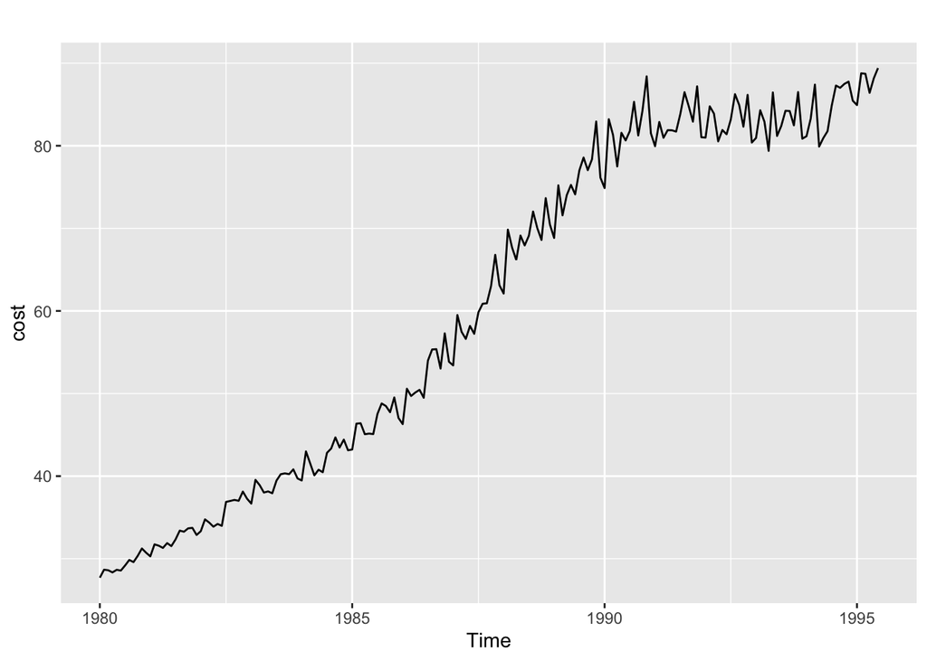

```r
autoplot(cost)
```

1. Plot the CPI and Cost time series.

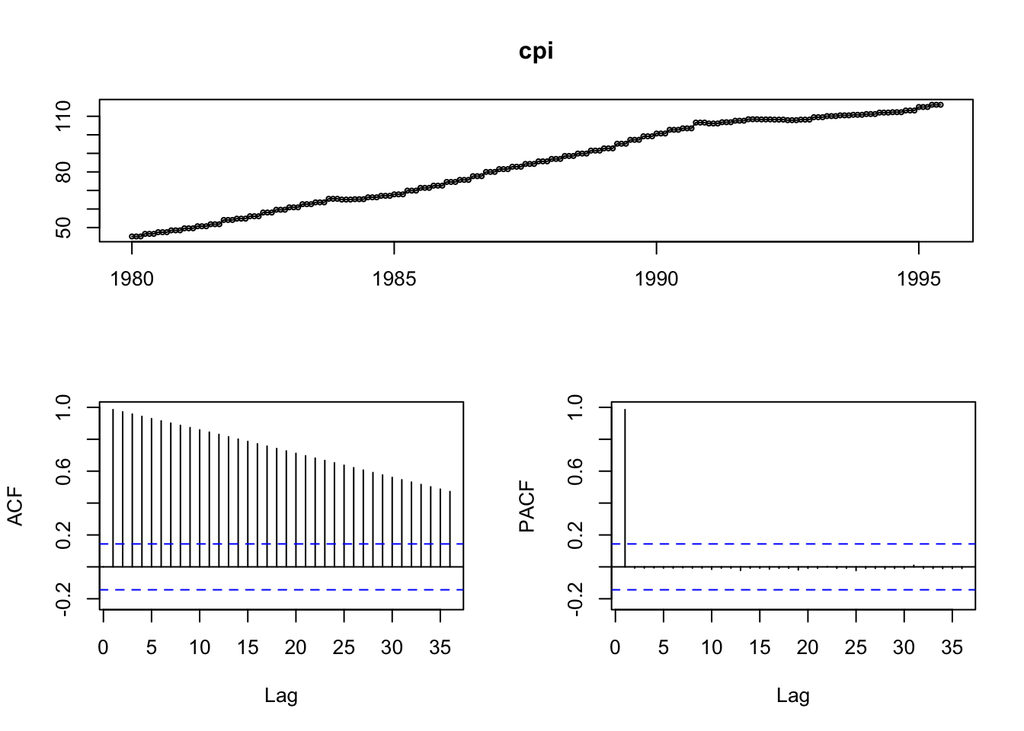

```r
tsdisplay(cpi)
```

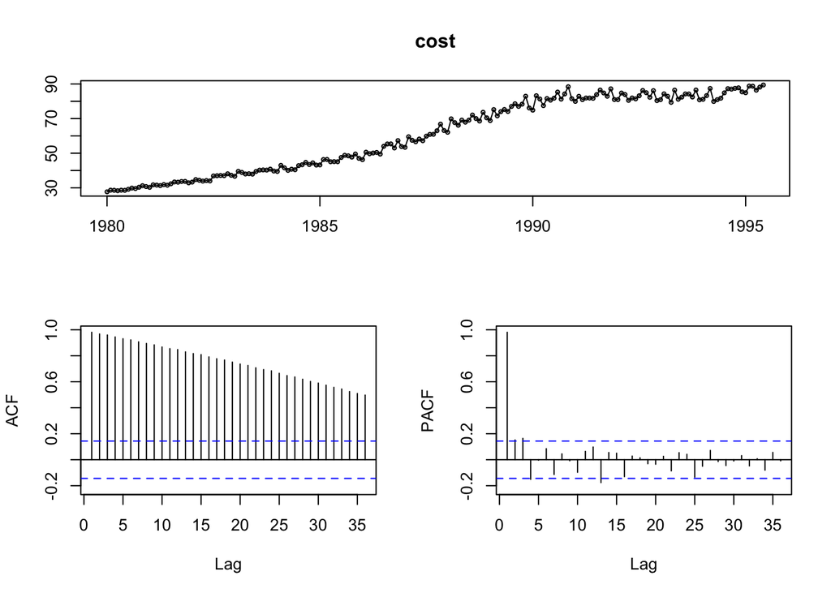

```r
tsdisplay(cost)
```

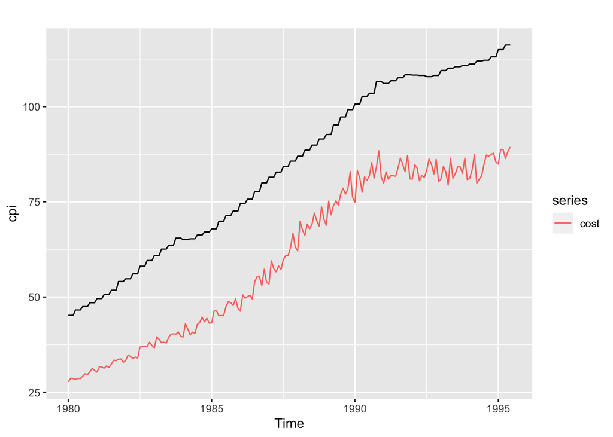

```r
autoplot(cpi)+autolayer(cost)
```

2. Plot the Cost time series against the CPI time series and calculate the correlation between CPI and Cost.

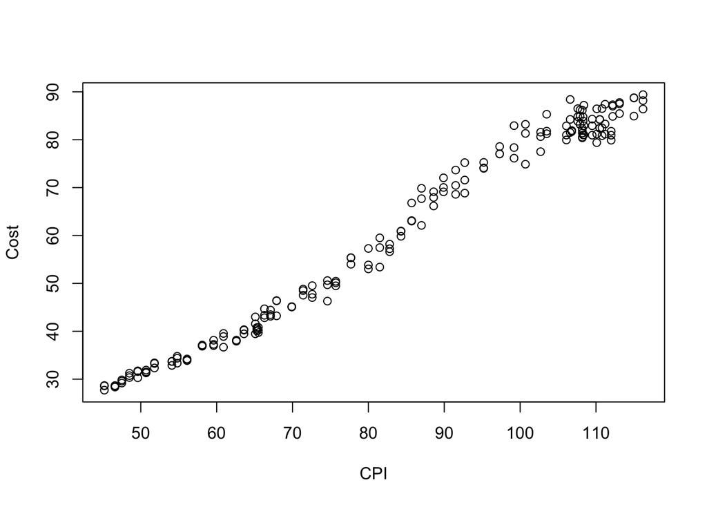

```r
plot(cpi, cost, xlab="CPI", ylab="Cost")
```

```r
cor(cpi,cost)
```

```
## [1] 0.9907186
```

Discuss your results and explain why the logarithms of both variables need to be taken before fitting any models.

Reason: From the time series plots, we know that the variance for both of them are changing as their means changing. In other words, the variance of both variables are not constant. Thus, we need the logarithms transformation for CPI and Cost to stabilize their variance.

Result: From the plot of cost against cpi, we can see that those two variables are strongly correlated with each other : as one increases, the other one also increases. They also have large value of correlation (0.9907186).

3. Plot the 𝑙𝑜𝑔(𝐶𝑃𝐼) and 𝑙𝑜𝑔(𝐶𝑜𝑠𝑡) time series and calculate the correlation between the logarithms of both CPI and Cost.

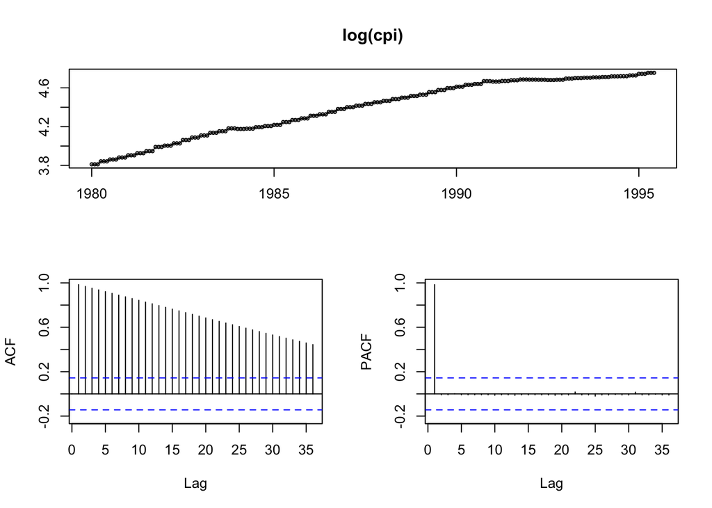

```r
tsdisplay(log(cpi))
```

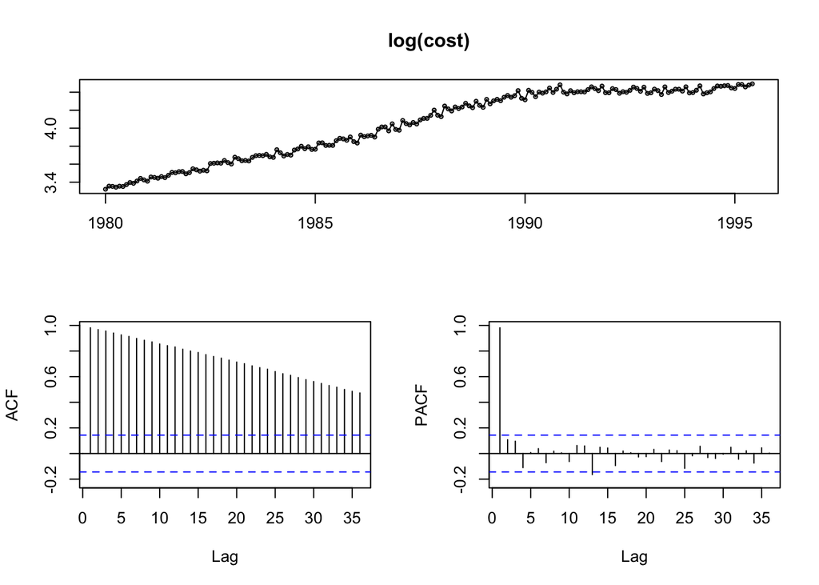

```r
tsdisplay(log(cost))
```

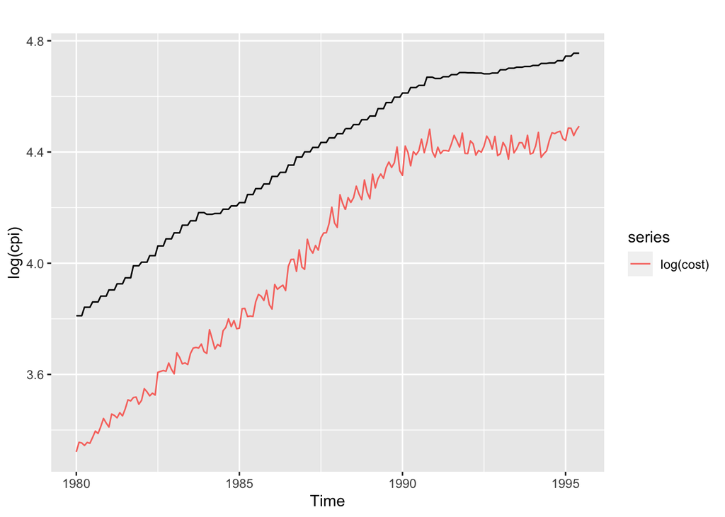

```r
autoplot(log(cpi)) + autolayer(log(cost))
```

```r
cor(log(cpi),log(cost))
```

```
## [1] 0.9929902
```

1. Use the linear model with time series components function tslm() to fit a linear model to the 𝑙𝑜𝑔(𝐶𝑜𝑠𝑡) time series as a function of the 𝑙𝑜𝑔(𝐶𝑃𝐼) time series (i.e., CPI ➔ Independent variable, Cost➔ Dependent variable).

```r
lm.cost_cpi <- tslm(log(cost) ~ log(cpi))
lm.cpi_cost <- tslm(log(cpi) ~ log(cost))
```

2. Plot 𝑙𝑜𝑔(𝐶𝑃𝐼) against 𝑙𝑜𝑔(𝐶𝑜𝑠𝑡) and the fitted trend.

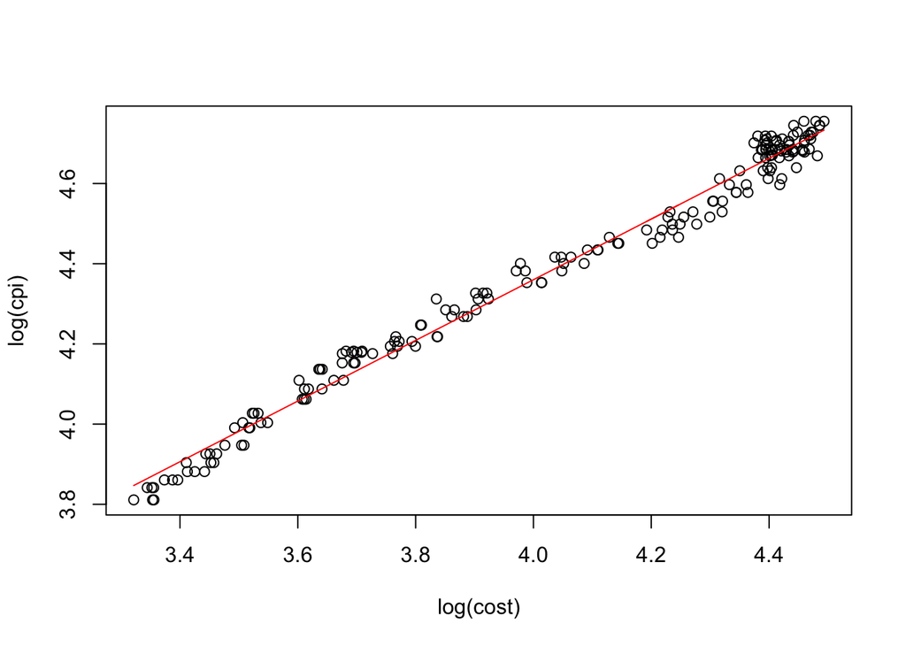

```r
plot(log(cost), log(cpi))
lines(as.numeric(log(cost)), lm.cpi_cost$fitted.values, type="l",col=2)
```

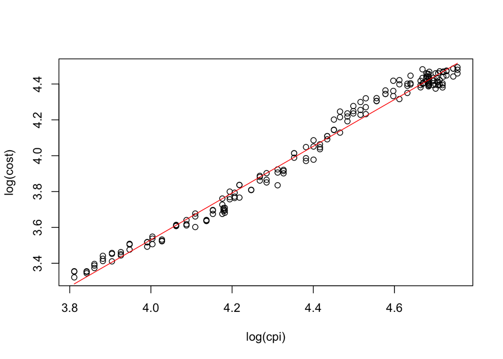

```r
plot(log(cpi), log(cost))
lines(as.numeric(log(cpi)), lm.cost_cpi$fitted.values, type="l",col=2)
```

3. Use the summary() function to summarize the generated model, and the checkresiduals() function to evaluate the residuals.

```r
summary(lm.cpi_cost)
```

```
##
## Call:
## tslm(formula = log(cpi) ~ log(cost))
##
## Residuals:
##       Min        1Q    Median        3Q       Max
## -0.080581 -0.023218  0.001853  0.026211  0.076713
##
## Coefficients:
##             Estimate Std. Error t value Pr(>|t|)
## (Intercept) 1.334126   0.026932   49.54   <2e-16 ***
## log(cost)   0.756510   0.006638  113.96   <2e-16 ***
## ---
## Signif. codes:  0 '***' 0.001 '**' 0.01 '*' 0.05 '.' 0.1 ' ' 1
##
## Residual standard error: 0.03418 on 184 degrees of freedom
## Multiple R-squared:  0.986,  Adjusted R-squared:  0.986
## F-statistic: 1.299e+04 on 1 and 184 DF,  p-value: < 2.2e-16
```

```r
summary(lm.cost_cpi)
```

```
##
## Call:
## tslm(formula = log(cost) ~ log(cpi))
##
## Residuals:
##       Min        1Q    Median        3Q       Max
## -0.102841 -0.033939 -0.002071  0.030363  0.108670
##
## Coefficients:
##             Estimate Std. Error t value Pr(>|t|)
## (Intercept) -1.68246    0.05032  -33.44   <2e-16 ***
## log(cpi)     1.30339    0.01144  113.96   <2e-16 ***
## ---
## Signif. codes:  0 '***' 0.001 '**' 0.01 '*' 0.05 '.' 0.1 ' ' 1
##
## Residual standard error: 0.04487 on 184 degrees of freedom
## Multiple R-squared:  0.986,  Adjusted R-squared:  0.986
## F-statistic: 1.299e+04 on 1 and 184 DF,  p-value: < 2.2e-16
```

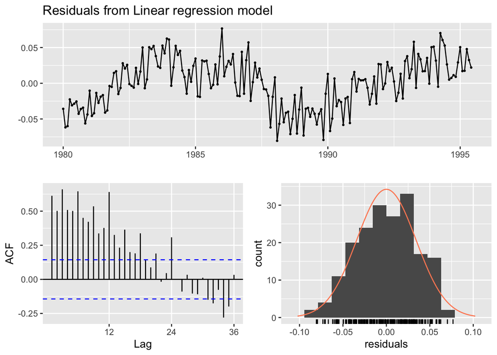

```
##
##  Breusch-Godfrey test for serial correlation of order up to 24
##
## data:  Residuals from Linear regression model
## LM test = 148.25, df = 24, p-value < 2.2e-16
```

```r
checkresiduals(lm.cpi_cost)
```

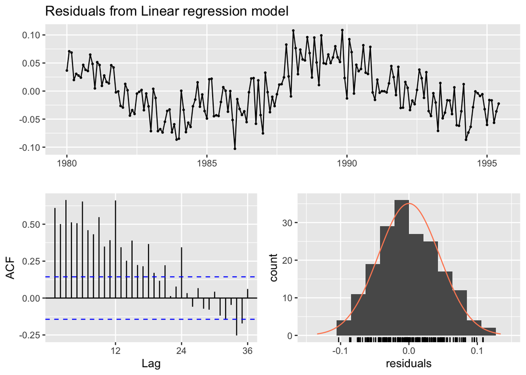

```
##
##  Breusch-Godfrey test for serial correlation of order up to 24
##
## data:  Residuals from Linear regression model
## LM test = 148.84, df = 24, p-value < 2.2e-16
```

```r
checkresiduals(lm.cost_cpi)
```

From the plot, we can see that those two variables are strongly correlated with each other and there is a clear positive trend.

The tslm() method fits a linear model to the log(cost) time series as a function of the log(cpi) time series, with a intercept of -1.682 and a slope of 1.303, meaning that for every 1 unit increase of log(cpi), there is 1.303 unit increase of log(cost). Same idea for the tslm() fitting to log(cpi) to log(cost), with 1.334 as the intercept and 0.757 as the slope.

In terms of the residuals of the tslm models, there are clearly some patterns remaining in the residuals and the plot of residuals is not white noise since the acf graph shows significant difference and the distribution is not normal enough.

3. Use the auto.arima() function to fit an appropriate regression model with ARIMA errors to the Cost and CPI time series(i.e., CPI ➔ Independent variable, Cost➔ Dependent variable). Set the Order of seasonaldifferencing argument, D, to 1 and the ‘lambda’ argument to 0 to reflect a logarithmic transformation.

```r
model.arima <- auto.arima(y=cost,xreg=cpi,D=1,lambda = 0)
```

1. Use the summary() function to summarize the generated model.

```r
summary(model.arima)
```

```
## Series: cost
## Regression with ARIMA(0,1,1)(0,1,2)[12] errors
## Box Cox transformation: lambda= 0
##
## Coefficients:
##           ma1     sma1    sma2    xreg
##       -0.5516  -0.6160  0.1374  0.0099
## s.e.   0.0602   0.0785  0.1009  0.0025
##
## sigma^2 estimated as 0.0003728:  log likelihood=437.07
## AIC=-864.14   AICc=-863.79   BIC=-848.38
##
## Training set error measures:
##                       ME     RMSE       MAE        MPE     MAPE      MASE
## Training set -0.08012207 1.307136 0.8968091 -0.1126491 1.349787 0.2115032
##                     ACF1
## Training set -0.06269298
```

2. Use the checkresiduals() function to evaluate the residuals.

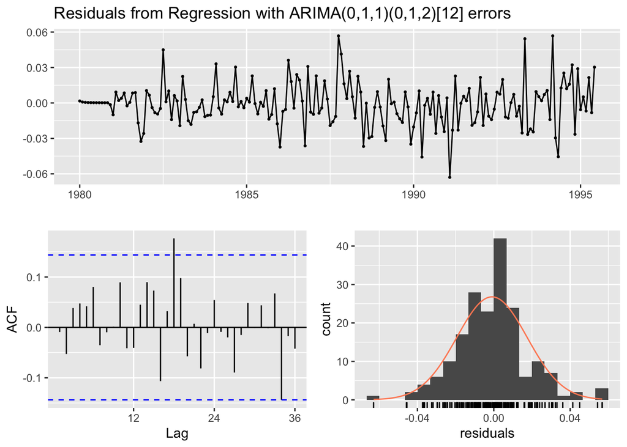

```
##
##  Ljung-Box test
##
## data:  Residuals from Regression with ARIMA(0,1,1)(0,1,2)[12] errors
## Q* = 22.342, df = 20, p-value = 0.3223
##
## Model df: 4.   Total lags used: 24
```

```r
checkresiduals(model.arima)
```

Discuss your results.

1. Calculate and plot a naïve forecast of CPI for the next 18 months.

```r
naive <- naive(cpi, h=18)
summary(naive)
```

```
##
## Forecast method: Naive method
##
## Model Information:
## Call: naive(y = cpi, h = 18)
##
## Residual sd: 0.7886
##
## Error measures:
##                     ME      RMSE       MAE       MPE      MAPE       MASE
## Training set 0.3837838 0.7886355 0.3989189 0.5047427 0.5214831 0.08598029
##                    ACF1
## Training set -0.3119863
##
## Forecasts:
##          Point Forecast    Lo 80    Hi 80    Lo 95    Hi 95
## Jul 1995          116.2 115.1893 117.2107 114.6543 117.7457
## Aug 1995          116.2 114.7707 117.6293 114.0141 118.3859
## Sep 1995          116.2 114.4495 117.9505 113.5228 118.8772
## Oct 1995          116.2 114.1786 118.2214 113.1086 119.2914
## Nov 1995          116.2 113.9401 118.4599 112.7437 119.6563
## Dec 1995          116.2 113.7244 118.6756 112.4138 119.9862
## Jan 1996          116.2 113.5260 118.8740 112.1105 120.2895
## Feb 1996          116.2 113.3414 119.0586 111.8281 120.5719
## Mar 1996          116.2 113.1680 119.2320 111.5629 120.8371
## Apr 1996          116.2 113.0040 119.3960 111.3121 121.0879
## May 1996          116.2 112.8480 119.5520 111.0735 121.3265
## Jun 1996          116.2 112.6989 119.7011 110.8455 121.5545
## Jul 1996          116.2 112.5560 119.8440 110.6269 121.7731
## Aug 1996          116.2 112.4184 119.9816 110.4165 121.9835
## Sep 1996          116.2 112.2857 120.1143 110.2135 122.1865
## Oct 1996          116.2 112.1573 120.2427 110.0172 122.3828
## Nov 1996          116.2 112.0329 120.3671 109.8269 122.5731
## Dec 1996          116.2 111.9121 120.4879 109.6422 122.7578
```

```r
naive$mean
```

```
##        Jan   Feb   Mar   Apr   May   Jun   Jul   Aug   Sep   Oct   Nov   Dec
## 1995                                     116.2 116.2 116.2 116.2 116.2 116.2
## 1996 116.2 116.2 116.2 116.2 116.2 116.2 116.2 116.2 116.2 116.2 116.2 116.2
```

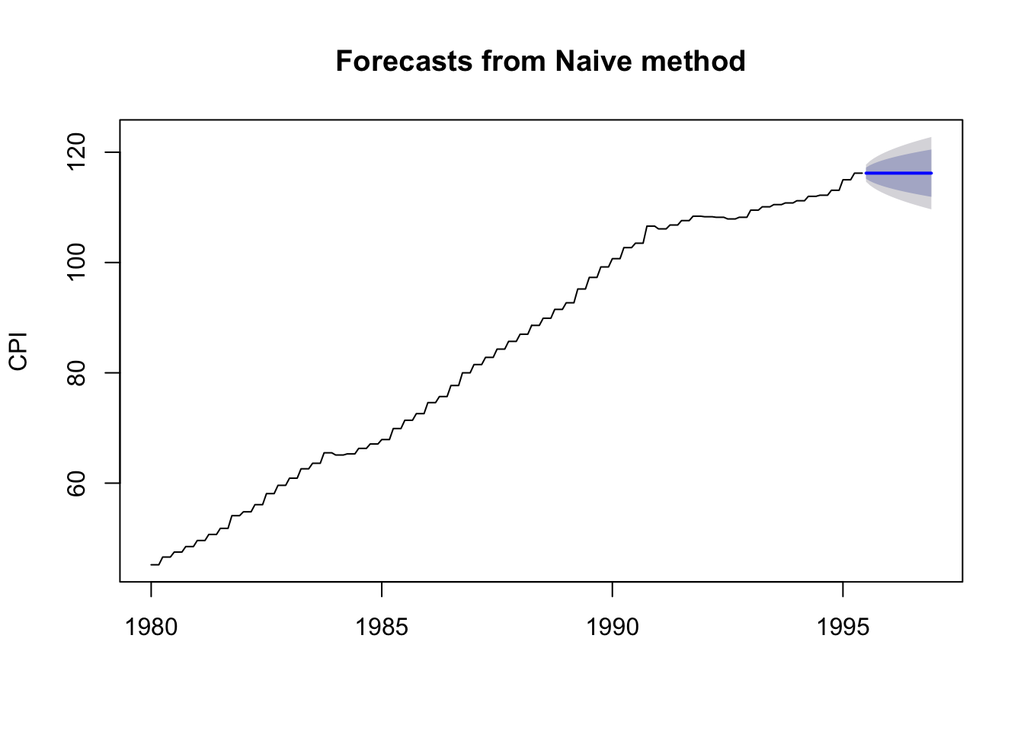

```r
plot(naive, ylab = 'CPI')
```

2. Forecast and plot the average price per room (i.e., Cost) for the next 18 months using the fitted model from Question 3 and the naïve forecast of CPI.

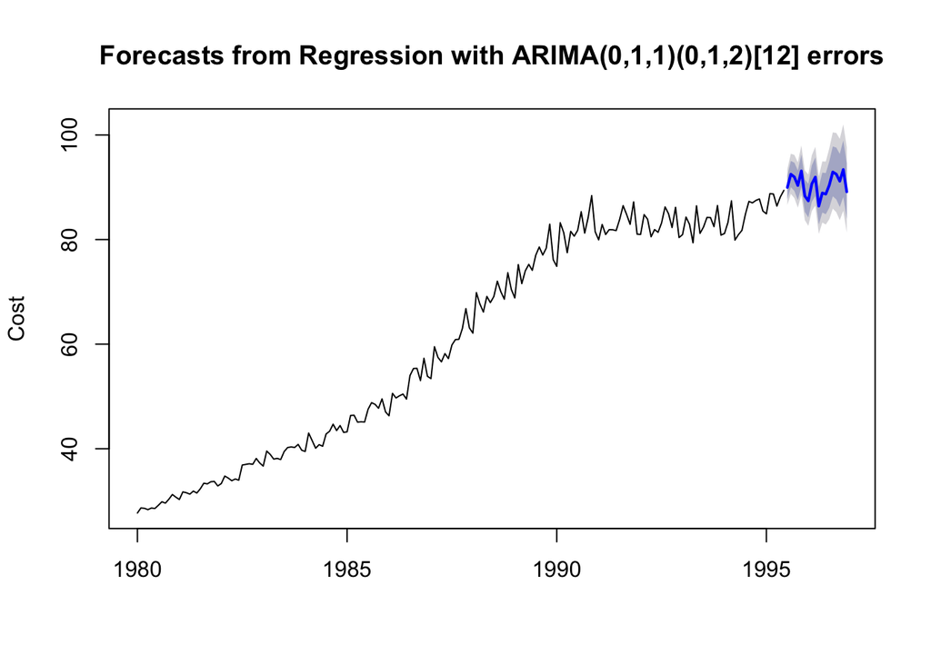

```r
arimafoc <- forecast(model.arima, h = 18, xreg = naive$mean)
plot(arimafoc, ylab = 'Cost')
```

Discuss your results.

We used the naive forecast to get the future values of cpi, assuming that the forecasted cpi is going to be constant for the future 18 months. Then we forecast the cost for next 18 months using the model of regression with arima and the predicted values of cpi and get the result with range. Since that the model counts for the correlation between dependent variable and independent variable, the forecasts should work better than simply using an arima model

1. Use the VAR() function to fit a VAR(10) model to the 𝑙𝑜𝑔(𝐶𝑜𝑠𝑡) and 𝑙𝑜𝑔(𝐶𝑃𝐼) time series. Set the ‘type’ and ‘season’ arguments to ‘both’ and 12, respectively.

```r
varfit <- VAR(cbind(log(cost),log(cpi)), p = 10, type = 'both', season = 12)
```

```r
summary(varfit)
```

```
##
## VAR Estimation Results:
## =========================
## Endogenous variables: log.cost., log.cpi.
## Deterministic variables: both
## Sample size: 176
## Log Likelihood: 1185.453
## Roots of the characteristic polynomial:
## 0.9752 0.9588 0.9588 0.9494 0.9494 0.8857 0.8857 0.8607 0.8607 0.858 0.858 0.7962 0.7962 0.7867 0.7765 0.7765 0.7244 0.7244 0.4201 0.4201
## Call:
## VAR(y = cbind(log(cost), log(cpi)), p = 10, type = "both", season = 12L)
##
##
## Estimation results for equation log.cost.:
## ==========================================
## log.cost. = log.cost..l1 + log.cpi..l1 + log.cost..l2 + log.cpi..l2 + log.cost..l3 + log.cpi..l3 + log.cost..l4 + log.cpi..l4 + log.cost..l5 + log.cpi..l5 + log.cost..l6 + log.cpi..l6 + log.cost..l7 + log.cpi..l7 + log.cost..l8 + log.cpi..l8 + log.cost..l9 + log.cpi..l9 + log.cost..l10 + log.cpi.…
##
##                 Estimate Std. Error t value Pr(>|t|)
## log.cost..l1   3.918e-01  8.566e-02   4.573 1.03e-05 ***
## log.cpi..l1    3.234e-02  3.326e-01   0.097  0.92268
## log.cost..l2   2.361e-01  9.172e-02   2.574  0.01107 *
## log.cpi..l2    5.203e-01  4.448e-01   1.170  0.24403
## log.cost..l3   2.619e-01  9.295e-02   2.818  0.00552 **
## log.cpi..l3   -3.801e-01  4.452e-01  -0.854  0.39463
## log.cost..l4   6.684e-02  9.548e-02   0.700  0.48503
## log.cpi..l4    2.113e-01  4.446e-01   0.475  0.63539
## log.cost..l5   1.064e-01  9.430e-02   1.128  0.26113
## log.cpi..l5   -7.446e-01  4.443e-01  -1.676  0.09596 .
## log.cost..l6   1.080e-01  9.370e-02   1.153  0.25095
## log.cpi..l6    5.488e-01  4.524e-01   1.213  0.22715
## log.cost..l7  -4.795e-02  9.377e-02  -0.511  0.60986
## log.cpi..l7   -1.154e-02  4.533e-01  -0.025  0.97972
## log.cost..l8  -1.478e-01  9.248e-02  -1.598  0.11216
## log.cpi..l8   -5.395e-02  4.469e-01  -0.121  0.90407
## log.cost..l9  -2.313e-02  9.246e-02  -0.250  0.80285
## log.cpi..l9    2.196e-01  4.515e-01   0.486  0.62744
## log.cost..l10 -5.534e-03  8.677e-02  -0.064  0.94924
## log.cpi..l10  -2.696e-01  3.302e-01  -0.817  0.41554
## const         -9.512e-02  1.711e-01  -0.556  0.57905
## trend         -3.844e-05  1.821e-04  -0.211  0.83310
```

[output cut: 62 more lines]

```
## Residual standard error: 0.004535 on 143 degrees of freedom
## Multiple R-Squared: 0.9998,  Adjusted R-squared: 0.9997
## F-statistic: 1.855e+04 on 32 and 143 DF,  p-value: < 2.2e-16
##
##
##
## Covariance matrix of residuals:
##           log.cost.  log.cpi.
## log.cost. 3.704e-04 1.699e-05
## log.cpi.  1.699e-05 2.057e-05
##
## Correlation matrix of residuals:
##           log.cost. log.cpi.
## log.cost.    1.0000   0.1947
## log.cpi.     0.1947   1.0000
```

2. Forecast and plot the average price per room (i.e., Cost) and CPI for the next 18 months using your fitted model.

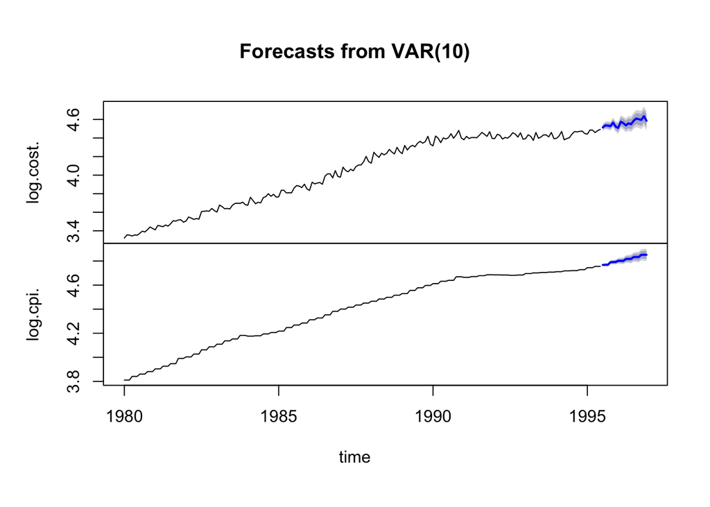

```r
varfoc <- forecast(varfit, h = 18)
plot(varfoc)
```

3. Plot the residuals’ ACF

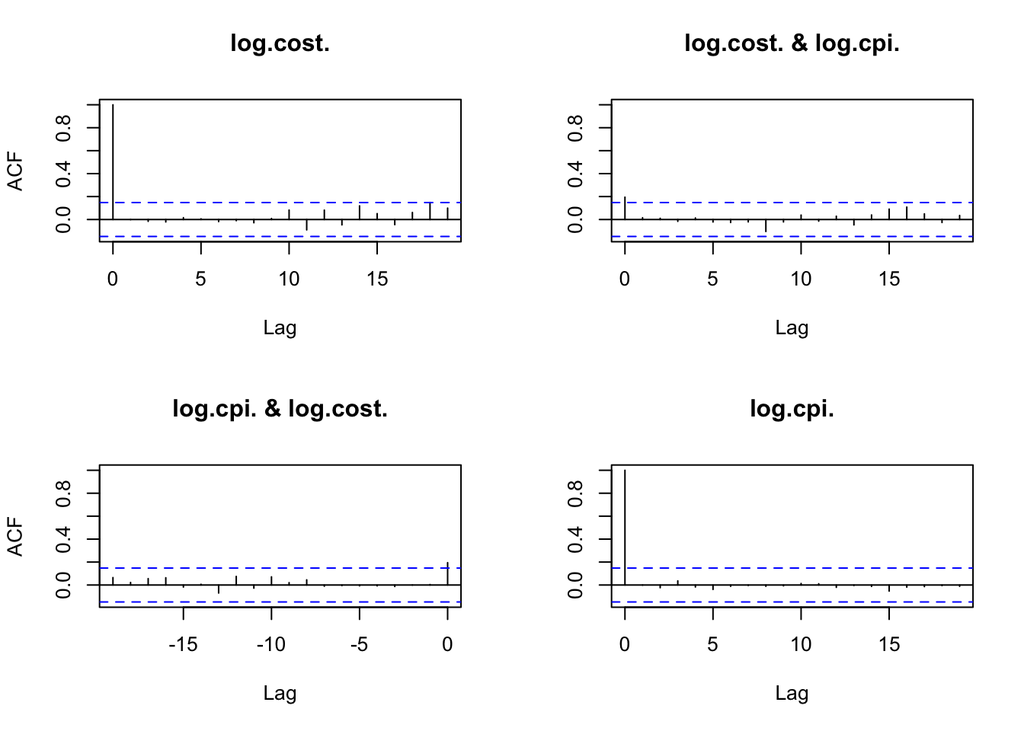

```r
acf(residuals(varfit))
```

Discuss your results.

The acf of residuals shows no sign of significant difference, which means that the residuals is white noise and the var() model captures enough information already.